# R for Econometrics: A Modest Handbook

Ryan Safner (safner@hood.edu)

Last Updated: Mon Oct 8 10:20:46 2018 -0400

> “There’s an implied contract between you and R: it will do the tedious computation for you, but in return, you must be completely precise in your instructions. Typos matter. Case matters.” - Hadley Wickham, [R for Data Science](http://r4ds.had.co.nz/workflow-basics.html)

**Note to Students**: This is a work in progress, check the date at the top for when this was last updated. This compiles all of my instructions, advice, and examples from econometrics class lectures regarding `R`. It also contains some advanced material that I did not or will not cover in class, but will be useful to know for future data analysis and understanding or diagnosing problems.

**Note to Everyone Else**: This guide is oriented primarily for my [Econometrics class](http://ryansafner.com/courses/econ480) at Hood College, but should be of wider use to anyone interested in learning `R` for data analysis.

# Basic Concepts

## Calculations

- `R` can be used as a calculator
  - Basic operations `+`, `-`, `*`, `/`
  - More advanced math operators like exponents, logarithms, trigonometric functions, etc

```r
2+2
```

```
## [1] 4
```

```r
6^2 # 6 to the second power (i.e. squared)
```

```
## [1] 36
```

```r
sqrt(100/4) # square root
```

```
## [1] 5
```

```r
log(5) # logarithm
```

```
## [1] 1.609438
```

```r
sin(2*pi) # sin
```

```
## [1] -2.449294e-16
```

```r
factorial(5) # factorial (e.g. 5!)
```

```
## [1] 120
```

```r
choose(2,6) # binomial choose function
```

```
## [1] 0
```

```r
# order of operations matters
3*3+4
```

```
## [1] 13
```

```r
3*(3+4)
```

```
## [1] 21
```

- `R` often reports very large (or very small) numbers in scientific notation with `e`
  - For positive `e`: the number of zeros (or digits after the decimal point) to the right of a number
    - e.g. $1.25e6 = 1.25 \times 10^6 = 1,250,000$
  - For negative `e`: one less than the number of zeros (or digits after the decimal point) to the left of a number
    - e.g. $1.25e-6 = 1.25 \times 10^{-6} = 0.00000125$

# Objects

## Vector

```r
c(1,2,3,4,5)
```

```
## [1] 1 2 3 4 5
```

- We can also build vectors via generating series

```r
1:5
```

```
## [1] 1 2 3 4 5
```

- We can perform mathematical operations on a vector as a whole:

```r
sum(1:5)
```

```
## [1] 15
```

```r
mean(1:5)
```

```
## [1] 3
```

- `R` is an programming language
- We will almost always store data in **objects** and run **functions** on objects
  - Objects are assigned values: `objectname<-value`
  - Functions take the form: `functionname(objectname)`
- Storing a vector as an object called “*x*” using the assignment operator “**<-**”

```r
x<-c(1,2,3,4,5)
```

- To inspect an object, we simply call it up by name

```r
x
```

```
## [1] 1 2 3 4 5
```

# Data Classes

- Vectors **must** contain the same type of elements (e.g. numerical or text)
- Technically this refers to **atomic vectors** (nearly all vectors are atomic)
- Vectors with “mixed” types will convert all elements to the lowest-common denominator, e.g. character
- You can always check the type of vector using **class()**

```r
mixed<-c(5, pi, TRUE, 4.3, "cabbage")
class(mixed)
```

```
## [1] "character"
```

### Numeric

- (aka “double”), as it sounds, can perform mathematical operations

```r
numeric<-c(1,2,3,4,5)
```

- There are two **types** of numeric objects: **double** and **integer**

### Double

```r
double<-c(pi,2.34,9.99)

class(double)
```

```
## [1] "numeric"
```

```r
typeof(double) # will return the more specific type
```

```
## [1] "double"
```

```r
is.double(double) # a logical test to see if object is "double" type
```

```
## [1] TRUE
```

```r
is.integer(double) # a logical test to see if object is "integer" type
```

```
## [1] FALSE
```

#### Integer

```r
integers<-c(1,2,3,4)
class(integers)
```

```
## [1] "numeric"
```

```r
typeof(integers)
```

```
## [1] "double"
```

```r
is.double(double)
```

```
## [1] TRUE
```

```r
is.integer(double)
```

```
## [1] FALSE
```

### Logical

- is a series of binary elements or statements that can either be TRUE or FALSE

```r
logical<-c(TRUE,FALSE,FALSE,TRUE)
```

- We can perform logical tests with common operators:
  - `<` less than
  - `>` greater than
  - `<=` less than or equal to ($\leq$)
  - `>=` greater than or equal to ($\geq$)
  - `==` is equal to (note two equals signs are needed!)
  - `!=` is not equal to
  - `%in%` is a member of a set ($\in$)

```r
3==4 #is 3 equal to 4?
```

```
## [1] FALSE
```

```r
3<4 # is three less than 4?
```

```
## [1] TRUE
```

```r
3<=4 # is three less than or equal to 4?
```

```
## [1] TRUE
```

```r
3>4 # is three greater than 4?
```

```
## [1] FALSE
```

```r
3!=4 # is three not equal to four?
```

```
## [1] TRUE
```

```r
3 %in% c(0,1,2) # is three in the following set of numbers?
```

```
## [1] FALSE
```

```r
3 %in% c(0,1,2,3) # is three in the following set of numbers?
```

```
## [1] TRUE
```

- We are not limited to using numeric data, `R` can also perform logical tests on other classes of variable, like characters (which need quotes):

```r
"red"=="blue" # is red the same as blue?
```

```
## [1] FALSE
```

```r
"red"!="blue" # is red not equal to blue?
```

```
## [1] TRUE
```

```r
political.party<-c("Republican","Democrat") # define political party as a set of Republican and Democrat
"Libertarian" %in% political.party # check if Libertarian is in the set of political parties we created
```

```
## [1] FALSE
```

```r
"Democrat" %in% political.party # check if Democrat is in our set of political parties
```

```
## [1] TRUE
```

- We can also perform more than one test at a time with multiple conditions:
  - `&` AND
  - `|` OR

```r
2==2 & 2>3 # is 2 equal to 2 AND greater than 3?
```

```
## [1] FALSE
```

```r
2==2 | 2>3 # is 2 equal to 2 OR greater than 3?
```

```
## [1] TRUE
```

- These commands will become very useful when we want to subset data or look at portions of our data based on some condition

### Character

- is a string of text: letters, numbers, and symbols, cannot perform mathematical operations
  - Character values require quotation marks around each value

```r
character<-c("one","two","7","orange")
```

#### Dates

- Dates are a specific type of character class
- Specific dates
  - Can do days, weeks, months, quarters, years

```r
today<-Sys.Date() #print today's date
format(today, format="%B %d %Y") # specify how to report date format
```

```
## [1] "October 08 2018"
```

```r
months<-seq(as.Date("2010/1/1"), as.Date("2012/1/1"), "months") # generate sequence of months between Jan 2010 and Jan 2012
months
```

```
##  [1] "2010-01-01" "2010-02-01" "2010-03-01" "2010-04-01" "2010-05-01"
##  [6] "2010-06-01" "2010-07-01" "2010-08-01" "2010-09-01" "2010-10-01"
## [11] "2010-11-01" "2010-12-01" "2011-01-01" "2011-02-01" "2011-03-01"
## [16] "2011-04-01" "2011-05-01" "2011-06-01" "2011-07-01" "2011-08-01"
## [21] "2011-09-01" "2011-10-01" "2011-11-01" "2011-12-01" "2012-01-01"
```

### Factor

- is a special type of character variable, often used to indicate membership in one of several possible categories, called **levels** (e.g. for plotting, or conditional statistics and data work)

```r
students<-factor(c("freshman", "senior", "senior", "junior", "freshman",
                   "sophomore", "freshman"))
students # note order is arbitrary
```

```
## [1] freshman  senior    senior    junior    freshman  sophomore freshman
## Levels: freshman junior senior sophomore
```

```r
levels(students) #extract unique levels
```

```
## [1] "freshman"  "junior"    "senior"    "sophomore"
```

```r
nlevels(students) #count the number of levels
```

```
## [1] 4
```

```r
table(students) #tabulate number of values for each level
```

```
## students
##  freshman    junior    senior sophomore
##         3         1         2         1
```

#### Ordered Factors

```r
students.o<-ordered(students, levels=c("freshman","sophomore","junior","senior"))
students.o
```

```
## [1] freshman  senior    senior    junior    freshman  sophomore freshman
## Levels: freshman < sophomore < junior < senior
```

- **Be advised**: when `R` stores and calls factors, it actually stores them as integers [1..k, for k categories] instead of characters (e.g. “freshman”=1, “sophomore”=2), making this a **nominal** variable. This allows for some mathematical operations.
- An **ordered factor** is where the ordering matters (e.g. “small”, “medium”, “large” coded as 1, 2, 3 in order)

## Checking or Reclassifying Objects

- We can always check the class of an object with `class()` or `typeof()`.
  - We can perform logical tests `is.numeric()`, `is.factor()`, etc. to see if an object is a specified type
  - We can change the class of an object by redefining it with `as.classname()`, e.g.

```r
is.numeric(x) # check if x is numeric
```

```
## [1] TRUE
```

```r
is.factor(x) # check if x is a character
```

```
## [1] FALSE
```

```r
x<-as.character(x) # change vector x to a character
class(x)
```

```
## [1] "character"
```

```r
x<-as.numeric(x) # change vector x back to numeric
class(x)
```

```
## [1] "numeric"
```

# Other Object Types

## Lists

```r
mylist<-list(5, pi, TRUE, 4.3, "cabbage")
class(mylist)
```

```
## [1] "list"
```

- Another great property of lists is that elements of the list can themselves be vectors

```r
vectored.list<-list(c(1.82, 1940, 93.20, 192.917),
     c("Orange", "Cyan", "Pink"),
     c(TRUE, FALSE, TRUE, TRUE, FALSE, TRUE, FALSE, FALSE))

str(vectored.list) # look at structure of the list
```

```
## List of 3
##  $ : num [1:4] 1.82 1940 93.2 192.92
##  $ : chr [1:3] "Orange" "Cyan" "Pink"
##  $ : logi [1:8] TRUE FALSE TRUE TRUE FALSE TRUE ...
```

- We can create a **label** for each element in a list, called a `name`

```r
vectored.list<-list(numbers=c(1.82, 1940, 93.20, 192.917), # first element is a vector called 'numbers'
     colors=c("Orange", "Cyan", "Pink"), # second element is a vector called `colors`
     logic=c(TRUE, FALSE, TRUE, TRUE, FALSE, TRUE, FALSE, FALSE)) # third element is a vector called `logic`

vectored.list
```

```
## $numbers
## [1]    1.820 1940.000   93.200  192.917
##
## $colors
## [1] "Orange" "Cyan"   "Pink"
##
## $logic
## [1]  TRUE FALSE  TRUE  TRUE FALSE  TRUE FALSE FALSE
```

- The `names` command prints (or changes) the name of the label of each element in the list

```r
names(vectored.list) # print the names of the list elements
```

```
## [1] "numbers" "colors"  "logic"
```

```r
names(vectored.list)<-c("name1","name2","name3") # rename the lables to 'name1', 'name2', and 'name3'

names(vectored.list) # print new names
```

```
## [1] "name1" "name2" "name3"
```

```r
vectored.list # print list with new names
```

```
## $name1
## [1]    1.820 1940.000   93.200  192.917
##
## $name2
## [1] "Orange" "Cyan"   "Pink"
##
## $name3
## [1]  TRUE FALSE  TRUE  TRUE FALSE  TRUE FALSE FALSE
```

## Matrix

```r
matrix1<-matrix(c(1,2,3,4,5,6),nrow=3) # make a 3-row matrix
matrix1
```

```
##      [,1] [,2]
## [1,]    1    4
## [2,]    2    5
## [3,]    3    6
```

## Data Frame

- The most important object in `R` is a **data frame** (what you call a “spreadsheet”), used for statistics, plots, regressions, etc
  - “Rectangular” data, rows are observations, columns are variables
  - Can hold variables of different classes (e.g. a quantitative variable like income, a character variable like name, etc)
  - In essence, data frames are actually lists (where each list object itself is a vector)
  - All vectors (columns) must have the same length!

```r
df<-data.frame(x = 1:3,
           y = c("a", "b", "c"),
           z = c(TRUE, FALSE, TRUE))
df
```

```
##   x y     z
## 1 1 a  TRUE
## 2 2 b FALSE
## 3 3 c  TRUE
```

# Manipulating Objects

## Indexing and Subsetting Objects

- `R` objects store multiple values as an ordered list
  - The order of each value is kept as an index number
    - e.g. the first value is [1], the second value is [2], the 82nd value is [82], etc.
- Use [square brackets] to isolate elements of a vector, index starts at [1]

```r
print(mylist) #Our original vector
```

```
## [[1]]
## [1] 5
##
## [[2]]
## [1] 3.141593
##
## [[3]]
## [1] TRUE
##
## [[4]]
## [1] 4.3
##
## [[5]]
## [1] "cabbage"
```

```r
mylist[1] #Inspect first element
```

```
## [[1]]
## [1] 5
```

```r
mylist[c(1,3)] #Inspect first and third elements
```

```
## [[1]]
## [1] 5
##
## [[2]]
## [1] TRUE
```

```r
mylist[2]<-"orange" #Change second element
print(mylist) #Our new vector
```

```
## [[1]]
## [1] 5
##
## [[2]]
## [1] "orange"
##
## [[3]]
## [1] TRUE
##
## [[4]]
## [1] 4.3
##
## [[5]]
## [1] "cabbage"
```

- We can also ask how many elements a vector contains with **length()**

```r
length(list)
```

```
## [1] 1
```

- We can also include expressions when requesting an indexed value

```r
#Get second-to-last value in list (length of list minus 1 value)
mylist[length(mylist)-1]
```

```
## [[1]]
## [1] 4.3
```

- It is often useful to label values (later, variables) by giving them “names”

```r
myvars<-c(Var1="alpha",Var2=12,Var3="height") #Label name goes first, then =, then the value
myvars
```

```
##     Var1     Var2     Var3
##  "alpha"     "12" "height"
```

```r
#We can still call specific values by index position
myvars[3] #Get 3rd value
```

```
##     Var3
## "height"
```

```r
#We can equivalently call up specific values by name
myvars["Var3"] #Get value of Var3
```

```
##     Var3
## "height"
```

```r
names(myvars) #List names of all values
```

```
## [1] "Var1" "Var2" "Var3"
```

```r
names(myvars)[3] #Get name of third value
```

```
## [1] "Var3"
```

# Plotting

## Base `R`

- Base `R` is very powerful and intuitive to plot, but not very sexy
- Basic syntax:

```r
plottype(data.frame.name$variable)
```

- If using multiple variables, you can avoid `$` by typing the variable names and then telling `R` where the variables come from (a data frame)

```r
plottype(variable1,variable2, data=data.frame.name)
```

### Histogram

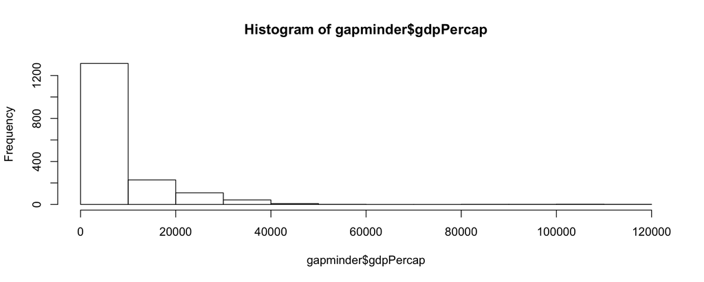

```r
library("gapminder")
hist(gapminder$gdpPercap)
```

### Boxplot

- Boxplots are similar syntax

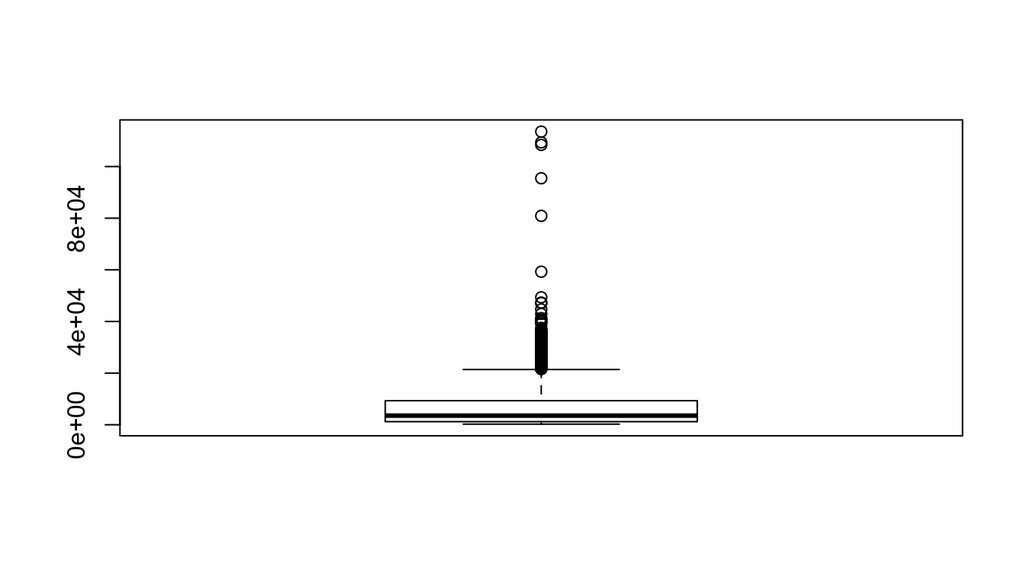

```r
boxplot(gapminder$gdpPercap)
```

- If we want a boxplot for each category, use `variable.name~category.variable.name` to tell `R` to plot a boxplot **by** category

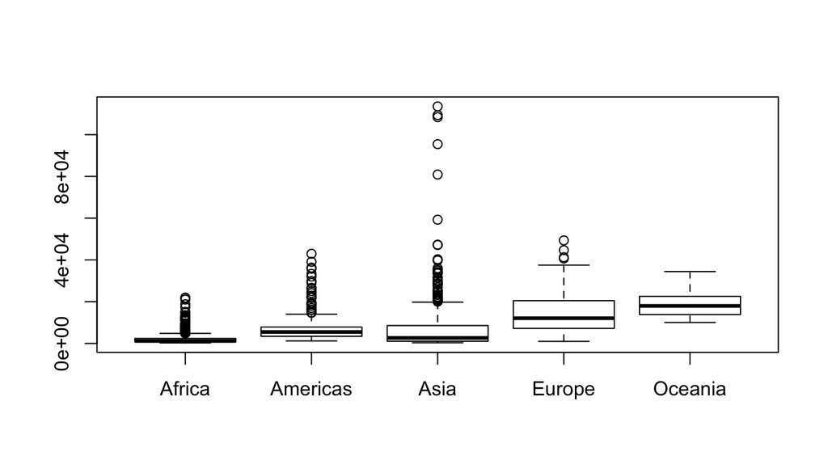

```r
boxplot(gdpPercap~continent,data=gapminder)
```

### Scatterplot

- Scatterplot syntax for plotting is similar to `hist()` and `boxplot()`: `plot(df$x,df$y)`

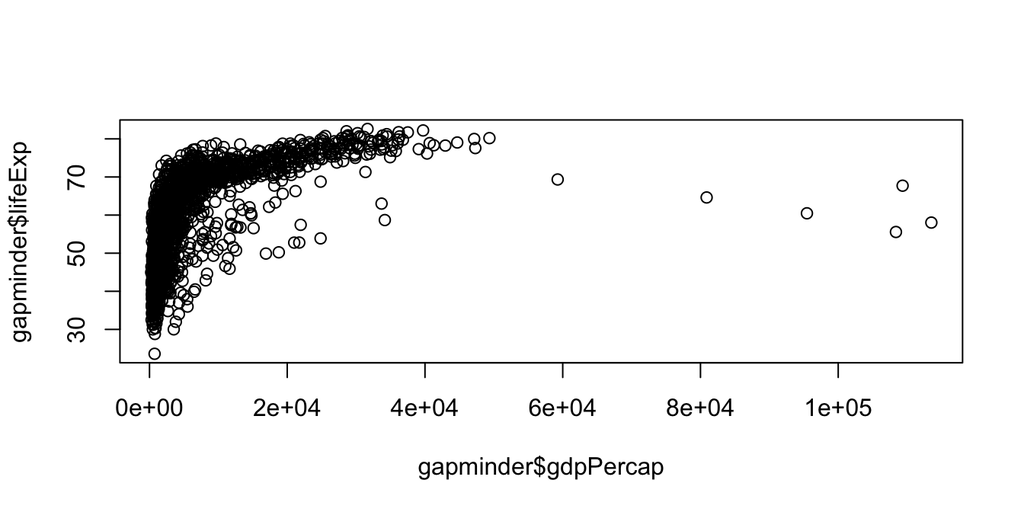

```r
plot(gapminder$gdpPercap, gapminder$lifeExp)
```

# Linear Regression

```r
sex<-c("Male", "Female")
marital<-c("Married","Unmarried")
```